# Neutrally slapping abundances on trees

A. J. Rominger

3/3/2018

Here I first re-construct the algorithms of Rosindell *et al.* (2010) *Ecology Letters* 13: 716–727 and then search for more efficient vectorized representations using known properties of the coalescent.

## Rosindell algorithms

These algorithms come from Appendix 1 of Rosindell *et al.* (2010).

### Point-mutation speciation in the metacommunity

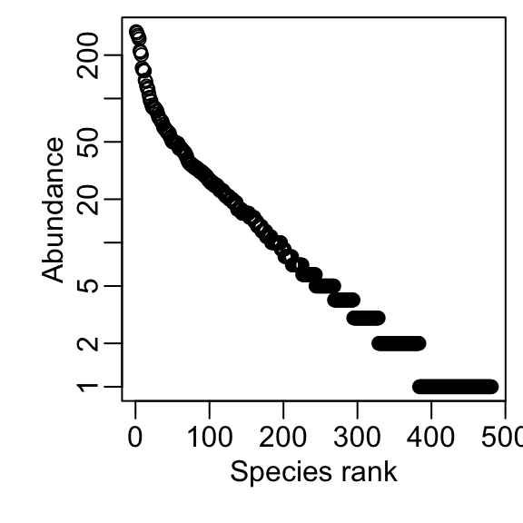

```r
# function to simulate meta community abundance under
# point mutation model of speciation

pointMutMeta <- function(theta, J) {
    # initialize with every lineage being one individual
    K <- J
    V <- rep(1, J)

    # this will hold the abundances of the final species
    W <- c()

    # loop until all lineages have coalesced
    while(K > 0) {
        # determines if we have speciation or coalescence
        r <- runif(1)

        # the lineage to which either event happens
        i <- sample(K, 1)

        # determine the event
        if(r <= theta / (theta + K - 1)) { # speciation
            W <- c(W, V[i])
            V <- V[-i]
        } else { # coalescence
            j <- sample((1:K)[-i], 1)
            V[i] <- V[i] + V[j]
            V <- V[-j]
        }

        # after either event, number of lineages is always
        # one less
        K <- K - 1
    }

    return(W)
}

# try it out
x <- pointMutMeta(theta = 100, J = 10^4)

par(mar = c(3, 3, 0, 0) + 0.5, mgp = c(1.5, 0.5, 0))
plot(sort(x, TRUE), log = 'y', xlab = 'Species rank', ylab = 'Abundance')
```

### Protracted speciation in the metacommunity

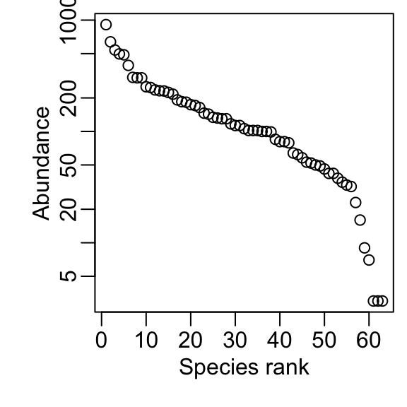

```r
# function to simulate meta community abundance under
# protracted model of speciation

protractMeta <- function(theta, J, tau) {
    taup <- tau / (J) # in units of generations, which themselves are in units of births
    V <- rep(1, J)
    K <- J
    W <- c()

    while(K > 0) {
        # total number of units of coalescence time that have passed
        t <- 0

        # determines how many generations until the next
        # coalescence event
        r <- runif(1)

        t <- t - log(r) / (K * (K - 1))

        if(taup > t) {  # coalescence without speciation
            ij <- sample(K, 2)
            V[ij[1]] <- sum(V[ij])
            V <- V[-ij[2]]
            K <- K - 1
        } else {  # point mut algo
            # the lineage to which either event happens
            i <- sample(K, 1)

            # determine the event
            if(r <= theta / (theta + K - 1)) { # speciation
                W <- c(W, V[i])
                V <- V[-i]
            } else { # coalescence
                j <- sample((1:K)[-i], 1)
                V[i] <- V[i] + V[j]
                V <- V[-j]
            }

            # after either event, number of lineages is always
            # one less
            K <- K - 1
        }

    }

    return(W)
}

# try it out
x <- protractMeta(100, 10^4, 2)

par(mar = c(3, 3, 0, 0) + 0.5, mgp = c(1.5, 0.5, 0))
plot(sort(x, TRUE), log = 'y', xlab = 'Species rank', ylab = 'Abundance')
```

## Vectorized coalescent

We need the tree topology and branch lengths as well. While we could easily get the topology from the above algorithms (recording the parent of each time `V[i]` merges with `V[j]` until speciation) the branch lengths would require a little more math—something for Rampal and James, not I! Additionally, in *R* these algorithms are slow for large $J$, though implementing them in *C++* would obviously be efficient. More direcetly simulating a coalescent process and then “sprinkling” (by a Poisson process) speciation events on that coalescent would give us everything we wanted.

The sojourn time in generations of $k$ lineages coalescing to $k - 1$ lineages is $\tau \sim exp\left\{\binom{k}{2}\right\}$. So we can simulate the coalescent sojourns this way

```r
J <- 10^3 # number of individuals
lambda <- 10 # point mutation speciation rate in generations

coalSoj <- rexp(J - 1, choose(J:2, 2)) # vector of sojourn times
```

Now we need the speciation events. These are just Poisson along every edge of the coalescent tree with equal rate

```r
# speciation happens according to a Poisson process, so we need
# to have a random number of speciation events, and place them
# uniformly randomly across all branches of the coalescent tree
nSpeciate <- rpois(1, lambda * sum(coalSoj * J:2)) # number of events

# ID of the sojourn times in which speciation occurs
sSpeciate <- sample(paste(rep((J-1):1, J:2), 1:sum(2:J), sep = '-'),
                    nSpeciate, replace = TRUE, prob = rep(coalSoj, J:2))
```

```r
# never mind
```